# Лабораторная работа №8

Анализ файловой системы Linux.Команды для работы с файлами и каталогами

Нилова Кристина

Российский университет дружбы народов, Москва, Россия

# Информация

## Докладчик

- Нилова Кристина
- студентка НБИбд-02-23
- Российский университет дружбы народов

# Вводная часть

## Вводная часть

В данной лабораторной работе мы рассмотрим: - Команды для работы с файлами и каталогами - Копирование файлов и каталогов - Перемещение и переименование файлов и каталогов - Права доступа - Изменение прав доступа - Анализ файловой системы

## Объект и предмет исследования

- Команда touch - Команда fsck - Команда mkfs - Команда kill
- Команда mount - Команда cat - Команда less - Команда ls
- Команда chmod - Команда rm - Команда cp - Команда mv

# Цель работы

## Цель работы

Целью лабораторной работы является ознакомление с файловой системой Linux, её структурой, именами и содержанием каталогов. Приобретение практических навыков по применению команд для работы с файлами и каталогами, по управлению процессами (и работами), по проверке исполь- зования диска и обслуживанию файловой системы.

# Выполнение лабораторной работы

# Первый этап

## 1

Запишим в файл file.txt названия файлов, содержащихся в каталоге /etc. Допи- шите в этот же файл названия файлов, содержащихся в вашем домашнем каталоге

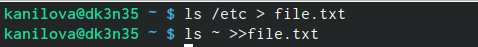

выполнение команды

# Второй этап

## 2

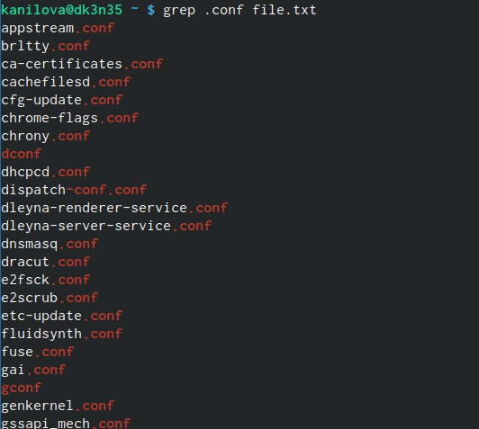

вывод файлов

## 2

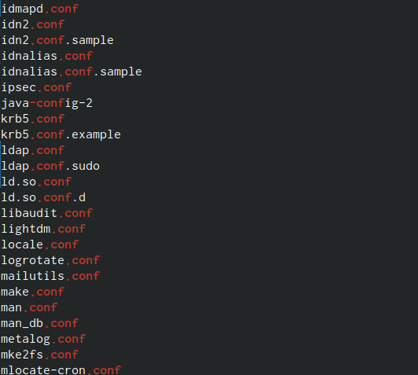

# Третий этап

## 3

Оределим какие файлы в домашнем каталоге начинаются с символа с.

[figure not shown]

## 3.1

[figure not shown]

выполнеине команды

## 3.1

[figure not shown]

выполнеине команды

## 3.2

Запустим в фоновом режиме процесс, который будет записывать в файл ~/logfile файлы, имена который начинаются с log, удалим logfile.

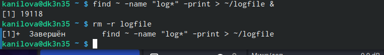

## 3.3 Запустим из консоли в фоновом редиме gedit.

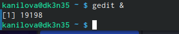

запуск gedit

## 4

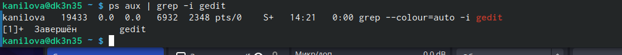

выполнение команды

## 4

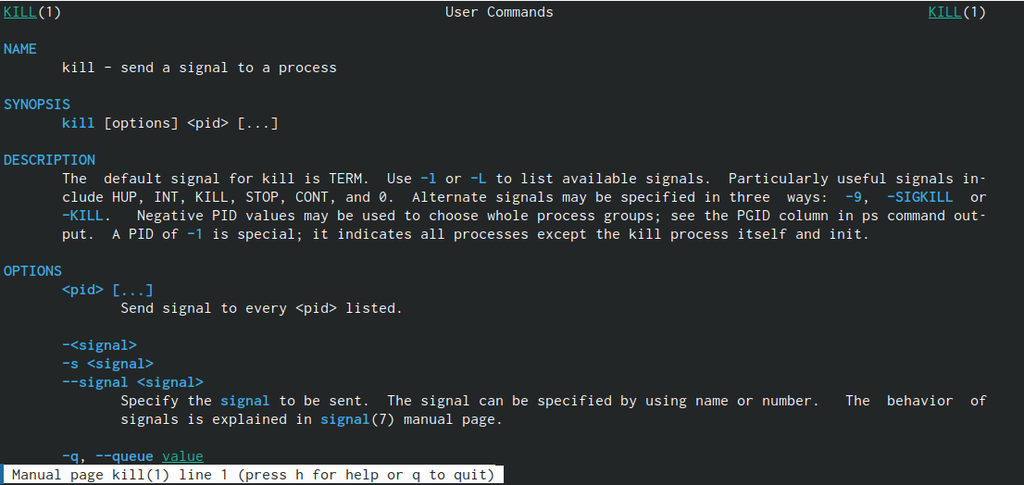

## 4

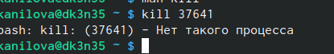

## 4

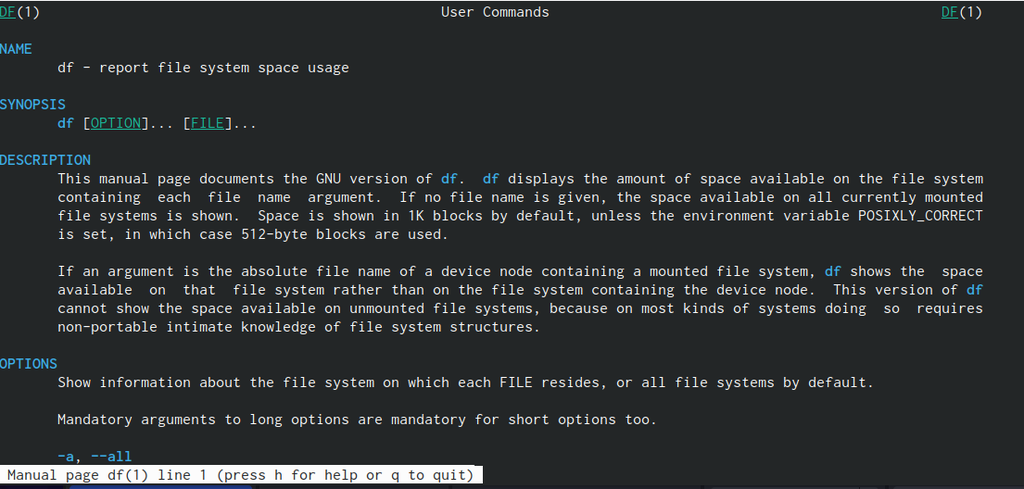

## 4

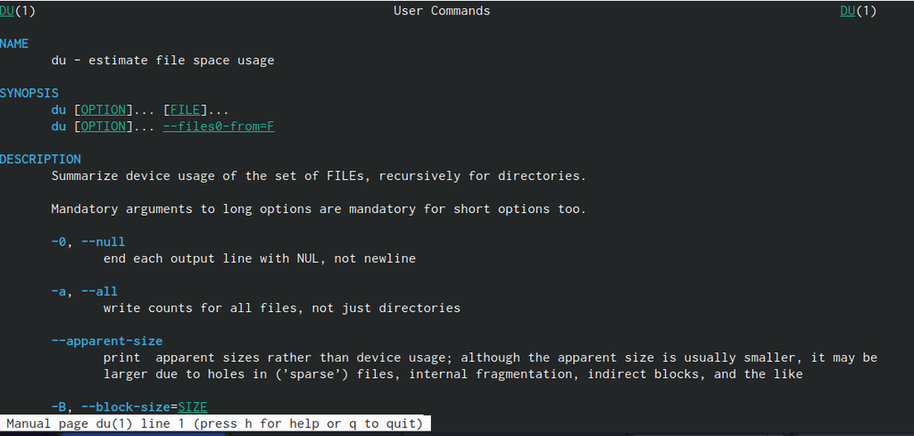

## 4

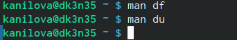

man du

# Пятый этап

## 5

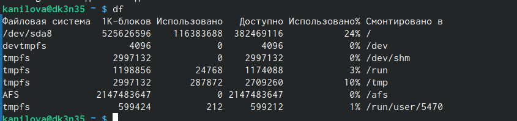

выполнение команды df

## 5

С помощью команды find выведем именя всех директорий

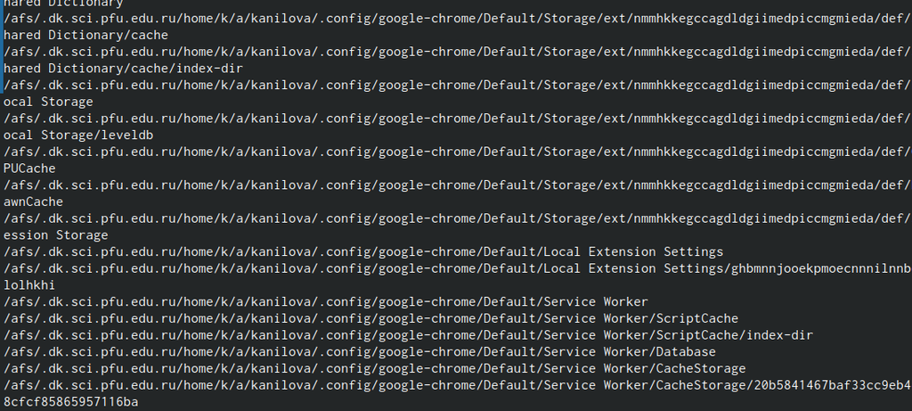

## 5

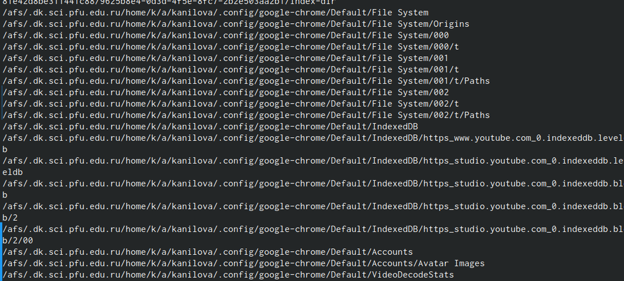

## 5

# Вывод

## Выводы

Мы ознакомились с файловой системой Linux, её структурой, именами и содержанием каталогов. Приобрели практические навыки по применению команд для работы с файлами и каталогами, по управлению процессами (и работами), по проверке исполь- зования диска и обслуживанию файловой системы.